# UB01

Anatol

3/19/2022

# Aufgabe 1: Einfache Regression

Deskription des Prestige-Datensatzes:

```r
summary(Prestige)
```

```
##    education          income          women           prestige
##  Min.   : 6.380   Min.   :  611   Min.   : 0.000   Min.   :14.80
##  1st Qu.: 8.445   1st Qu.: 4106   1st Qu.: 3.592   1st Qu.:35.23
##  Median :10.540   Median : 5930   Median :13.600   Median :43.60
##  Mean   :10.738   Mean   : 6798   Mean   :28.979   Mean   :46.83
##  3rd Qu.:12.648   3rd Qu.: 8187   3rd Qu.:52.203   3rd Qu.:59.27
##  Max.   :15.970   Max.   :25879   Max.   :97.510   Max.   :87.20
##      census       type
##  Min.   :1113   bc  :44
##  1st Qu.:3120   prof:31
##  Median :5135   wc  :23
##  Mean   :5402   NA's: 4
##  3rd Qu.:8312
##  Max.   :9517
```

```r
str(Prestige)
```

```
## 'data.frame':    102 obs. of  6 variables:
##  $ education: num  13.1 12.3 12.8 11.4 14.6 ...
##  $ income   : int  12351 25879 9271 8865 8403 11030 8258 14163 11377 11023 ...
##  $ women    : num  11.16 4.02 15.7 9.11 11.68 ...
##  $ prestige : num  68.8 69.1 63.4 56.8 73.5 77.6 72.6 78.1 73.1 68.8 ...
##  $ census   : int  1113 1130 1171 1175 2111 2113 2133 2141 2143 2153 ...
##  $ type     : Factor w/ 3 levels "bc","prof","wc": 2 2 2 2 2 2 2 2 2 2 ...
```

```r
head(Prestige)
```

|  | education | income | women | prestige | census | type |
| --- | --- | --- | --- | --- | --- | --- |
| gov.administrators | 13.11 | 12351 | 11.16 | 68.8 | 1113 | prof |
| general.managers | 12.26 | 25879 | 4.02 | 69.1 | 1130 | prof |
| accountants | 12.77 | 9271 | 15.70 | 63.4 | 1171 | prof |
| purchasing.officers | 11.42 | 8865 | 9.11 | 56.8 | 1175 | prof |
| chemists | 14.62 | 8403 | 11.68 | 73.5 | 2111 | prof |
| physicists | 15.64 | 11030 | 5.13 | 77.6 | 2113 | prof |

Bei der Variable type gibt es 4 NA’s, die wir weglassen:

```r
data <- na.omit(Prestige)
str(data)
```

```
## 'data.frame':    98 obs. of  6 variables:
##  $ education: num  13.1 12.3 12.8 11.4 14.6 ...
##  $ income   : int  12351 25879 9271 8865 8403 11030 8258 14163 11377 11023 ...
##  $ women    : num  11.16 4.02 15.7 9.11 11.68 ...
##  $ prestige : num  68.8 69.1 63.4 56.8 73.5 77.6 72.6 78.1 73.1 68.8 ...
##  $ census   : int  1113 1130 1171 1175 2111 2113 2133 2141 2143 2153 ...
##  $ type     : Factor w/ 3 levels "bc","prof","wc": 2 2 2 2 2 2 2 2 2 2 ...
##  - attr(*, "na.action")= 'omit' Named int [1:4] 34 53 63 67
##   ..- attr(*, "names")= chr [1:4] "athletes" "newsboys" "babysitters" "farmers"
```

## 1a)

*Analysieren Sie das Einkommen (income) in den verschiedenen Berufstypen (type). Unterscheiden sich die einzelnen Berufstypen hinsichtlich ihres Einkommens? Fallt Ihnen eine speziﬁsche Problematik auf, welche viele Datensatze in der Praxis haben?*

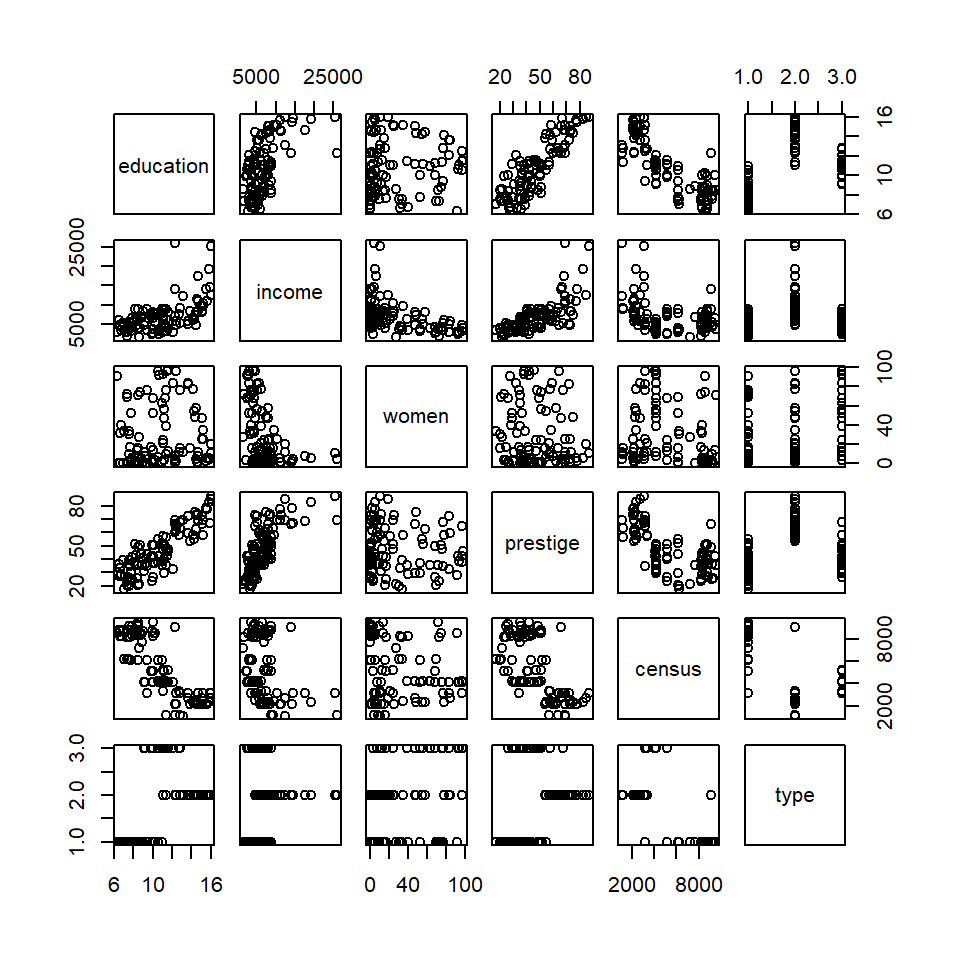

```r
plot(data)
```

Die Plots sind hisichtlich der Hauptachse spiegelverkehrt.  
*prestige gegen women*: man kann keinen Zusammenhang im Scatterplot beobachten.  
*prestige gegen income*: hier lässt sich ein positiver Zusammenhang beobachten: mehr Income, mehr Prestge. Der Zusammenhang ist aber nicht linear.  
*prestige gegen education*: **klarer positver linearer Zusammenhang: mit mehr Bildung geht mehr Prestige einher.**  
*prestige gegen census*: schwer zu interpretieren.  
*prestige gegen type*: es gibt ein Zusammenhang zwischen Jobtyp und Prestige.

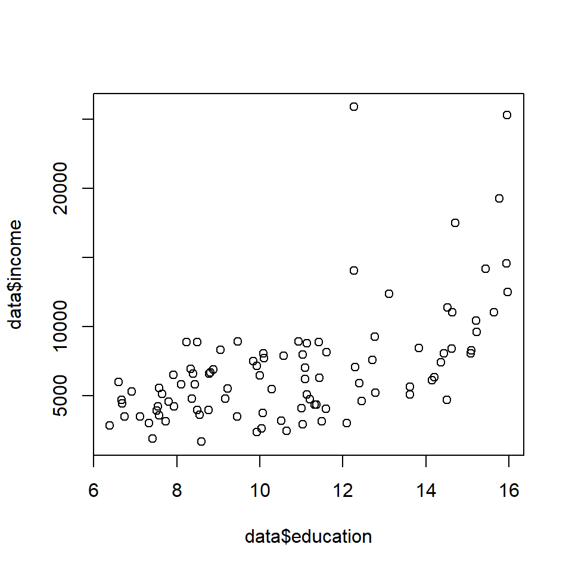

```r
plot(data$education, data$income)
```

Es scheint ein positiver linearer Zusammenhang zwischen Bildung und Einkommen zu geben.

Boxplots

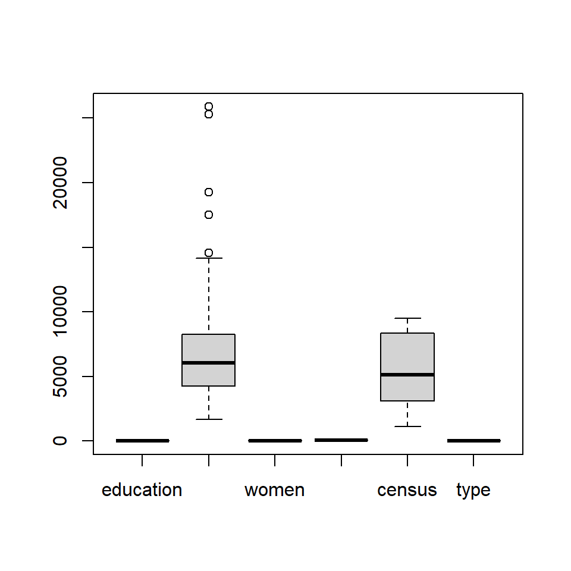

```r
boxplot(data)
```

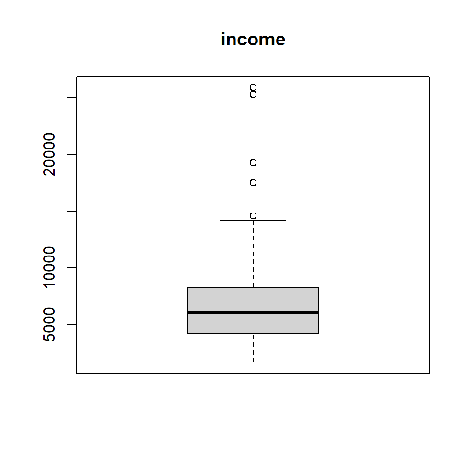

```r
boxplot(data$income, main = colnames(data)[2])
```

Berufsgruppen mit NA

```r
rownames(Prestige)[is.na(Prestige$type)]
```

```
## [1] "athletes"    "newsboys"    "babysitters" "farmers"
```

athletes, newsboys, babysitters and farmers konnten keiner Gruppe zugeordnet werden.  
Durchschnittliches Einkommen in verschiedenen Job-Typen:

```r
tapply(data$income, data$type, mean)
```

```
##        bc      prof        wc
##  5374.136 10559.452  5052.304
```

```r
tapply(data$income, data$type, median)
```

```
##     bc   prof     wc
## 5216.5 8865.0 4741.0
```

```r
tapply(data$income, data$type, min)
```

```
##   bc prof   wc
## 1656 4614 2448
```

```r
tapply(data$income, data$type, max)
```

```
##    bc  prof    wc
##  8895 25879  8780
```

```r
tapply(data$income, data$type, sd)
```

```
##       bc     prof       wc
## 2004.330 5422.818 1944.325
```

Metrische Variablen

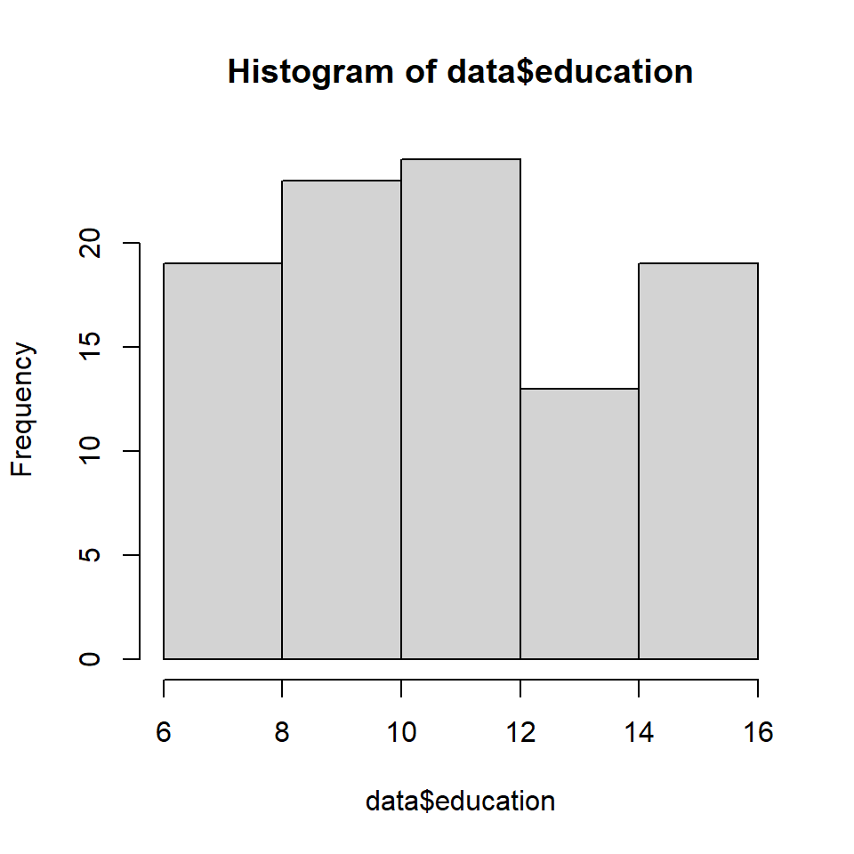

```r
hist(data$education, breaks = 5)
```

Density

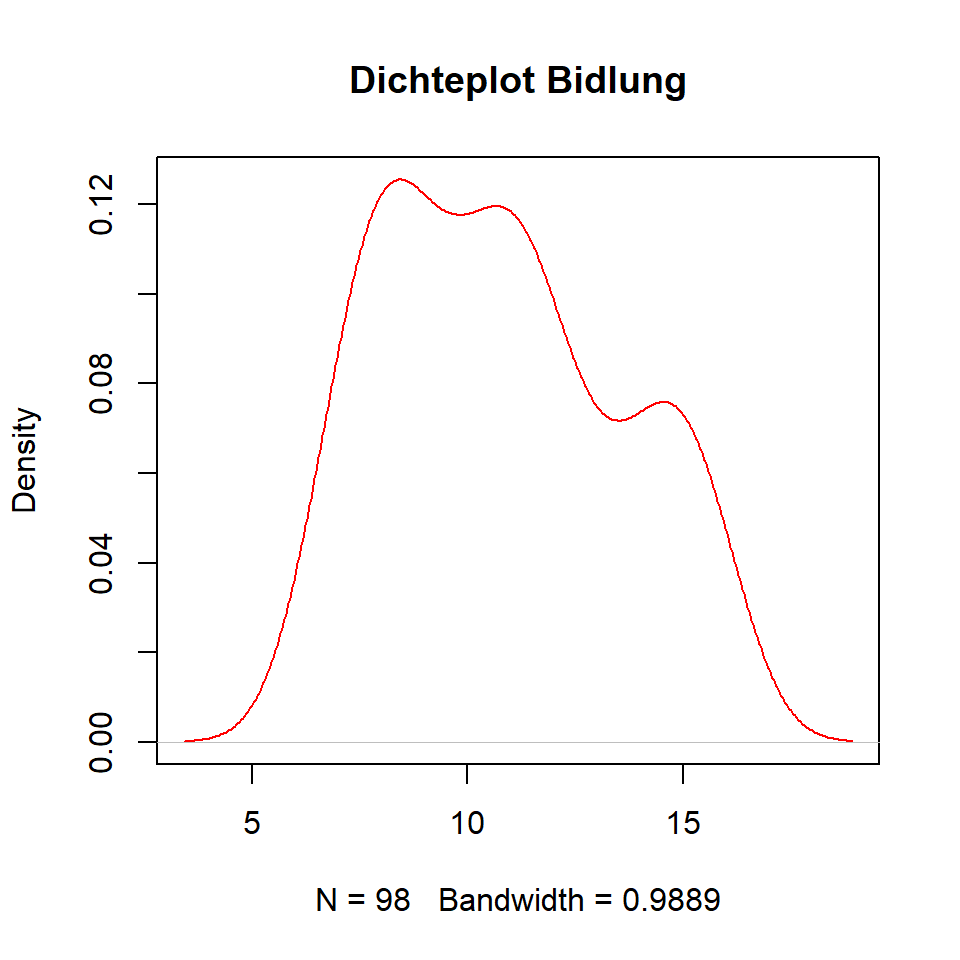

```r
plot(density(data$education), main = "Dichteplot Bidlung", col = "red")
```

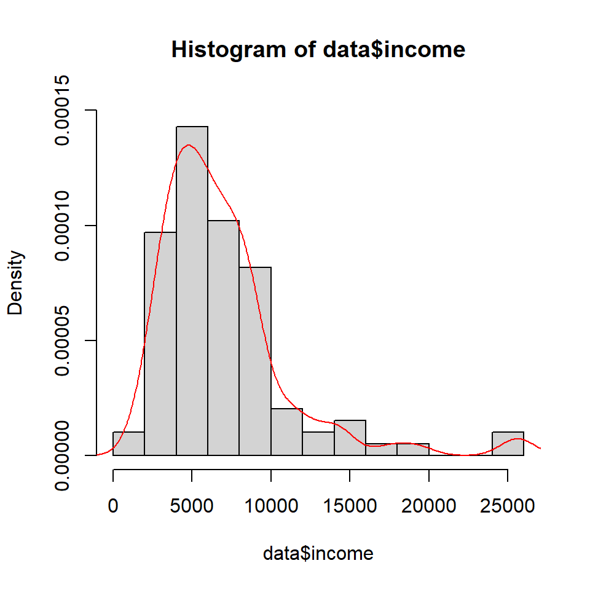

```r
hist(data$income, prob = TRUE, ylim = c(0, 0.00015), breaks = 17)
lines(density(data$income), col = "red")
```

```r
table(data$type)
```

```
##
##   bc prof   wc
##   44   31   23
```

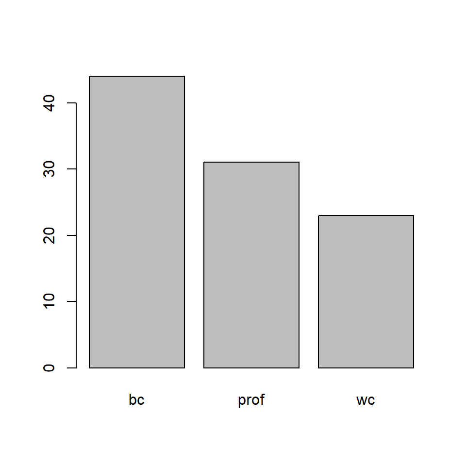

```r
barplot(table(data$type))
```

Einzelne Berufstypen unterscheiden sich hinsichtlich ihres Einkommens: wahrend blue-collar und white-collar Arbeiter ungefahr gleich verdienen, haben professionals deutlich hoheres Einkommen.

Viele Datensatze haben in der Praxis die Problematik der fehlenden Werte in Beobachtungen (missing values, NA).

## 1b)

*Schatzen Sie, basierend auf a), ein geeignetes lineares Regressionsmodell. Beschranken Sie sich hierbei auf eine erklarende Variable. Stellen Sie ihr Modell graﬁsch mit einer roten Regressionsgeraden dar. Nutzen Sie die Funktion lm um ein lm-Objekt zu erstellen. Die Funktion abline nimmt auch solche Objekte als Argument an.*

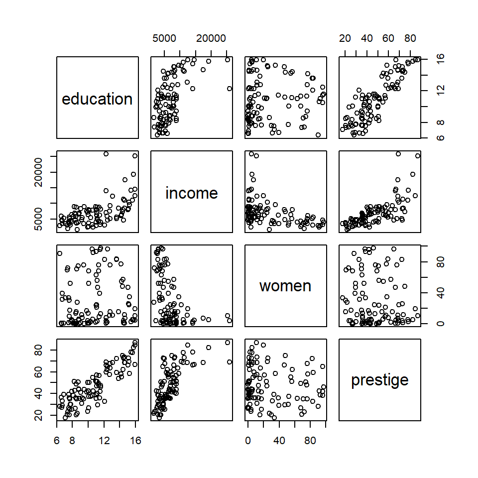

```r
plot(data[, 1:4])
```

Es scheint starker positiver linearer Zusammenhang zwischen prestige und education zu geben.

Einfaches lineares Regressionsmodell

```r
lin_reg <- lm(prestige ~ education, data = data)
summary(lin_reg)
```

```
##
## Call:
## lm(formula = prestige ~ education, data = data)
##
## Residuals:
##     Min      1Q  Median      3Q     Max
## -21.605  -6.151   0.366   6.565  17.540
##
## Coefficients:
##             Estimate Std. Error t value Pr(>|t|)
## (Intercept) -10.8409     3.5285  -3.072  0.00276 **
## education     5.3884     0.3168  17.006  < 2e-16 ***
## ---
## Signif. codes:  0 '***' 0.001 '**' 0.01 '*' 0.05 '.' 0.1 ' ' 1
##
## Residual standard error: 8.578 on 96 degrees of freedom
## Multiple R-squared:  0.7508, Adjusted R-squared:  0.7482
## F-statistic: 289.2 on 1 and 96 DF,  p-value: < 2.2e-16
```

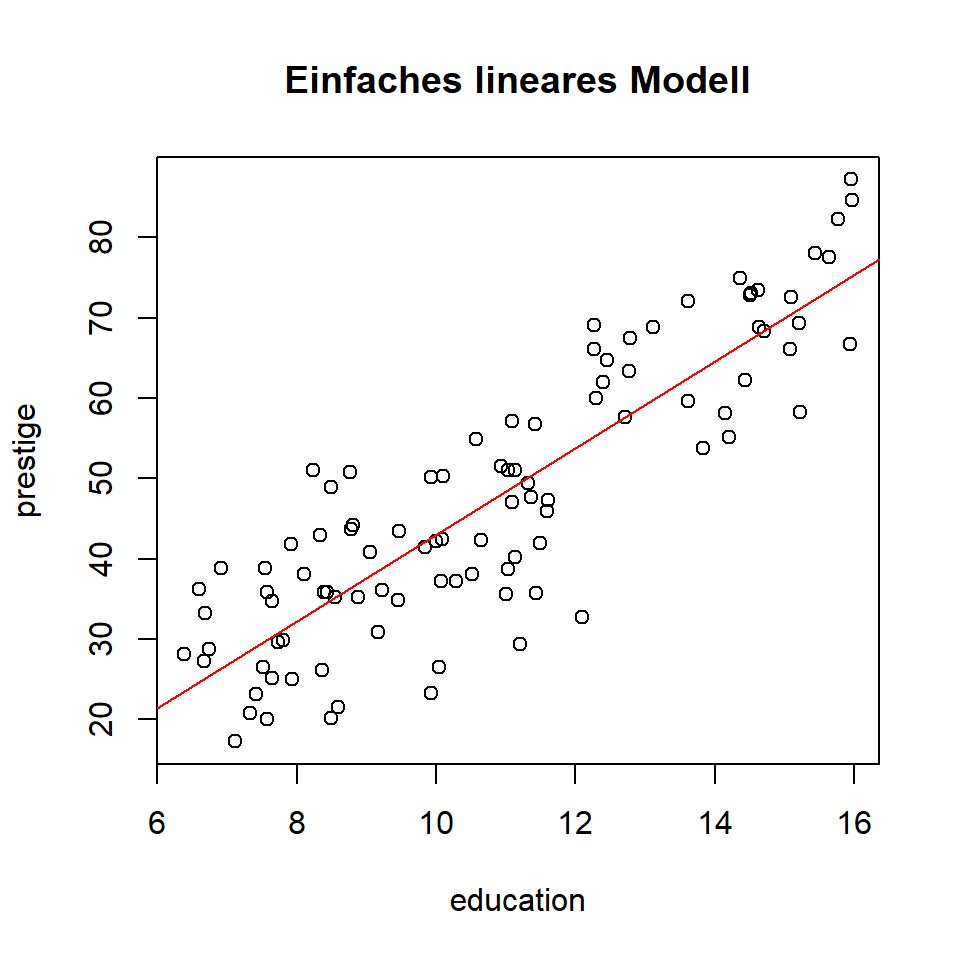

```r
plot(prestige ~ education, data = data, main = "Einfaches lineares Modell")
abline(lin_reg, col = "red")
```

## 1c)

*Berechnen Sie die Parameterschatzer $β_0$ und $β_1$ mit der Kleinste-Quadrate-Methode.*

```r
y <- data$prestige
x <- data$education
n <- nrow(data)

y_mean <- mean(y)
x_mean <- mean(x)

beta1 <- (sum(x*y) - n*x_mean*y_mean)/(sum(x^2) - n*x_mean^2)

beta1
```

```
## [1] 5.388408
```

```r
lin_reg$coefficients[2]
```

```
## education
##  5.388408
```

```r
cov(data$prestige, data$education)/var(data$education)
```

```
## [1] 5.388408
```

```r
beta0 <- (sum(x*y) - beta1*sum(x^2))/sum(x)

beta0
```

```
## [1] -10.84086
```

```r
lin_reg$coefficients[1]
```

```
## (Intercept)
##   -10.84086
```

```r
y_mean - beta1*x_mean
```

```
## [1] -10.84086
```

## 1d)

*Berechnen Sie die total sum of squares (SST), die explained sum of squares (SSE) und die residual sum of squares (SSR).*

```r
y_pred <- predict(lin_reg, data.frame(education=x))

sst <- sum((y - y_mean)^2)
sse <- sum((y_pred - y_mean)^2)
ssr <- sum((y - y_pred)^2)

sst
```

```
## [1] 28346.88
```

```r
sse
```

```
## [1] 21282.47
```

```r
ssr
```

```
## [1] 7064.405
```

## 1e)

*Berechnen Sie das $R^2$ Ihres Modells.*

```r
sse/sst
```

```
## [1] 0.7507872
```

```r
1 - ssr/sst
```

```
## [1] 0.7507872
```

## 1f)

*Was passiert mit den Parameterschatzern wenn Sie die abhangige Variable mit 2 multiplizieren? Wie verhalt sich in diesem Fall das $R^2$ des Modells?*

```r
lin_reg_mul <- lm(y*2 ~ x)
summary(lin_reg_mul)
```

```
##
## Call:
## lm(formula = y * 2 ~ x)
##
## Residuals:
##     Min      1Q  Median      3Q     Max
## -43.210 -12.301   0.732  13.130  35.081
##
## Coefficients:
##             Estimate Std. Error t value Pr(>|t|)
## (Intercept) -21.6817     7.0569  -3.072  0.00276 **
## x            10.7768     0.6337  17.006  < 2e-16 ***
## ---
## Signif. codes:  0 '***' 0.001 '**' 0.01 '*' 0.05 '.' 0.1 ' ' 1
##
## Residual standard error: 17.16 on 96 degrees of freedom
## Multiple R-squared:  0.7508, Adjusted R-squared:  0.7482
## F-statistic: 289.2 on 1 and 96 DF,  p-value: < 2.2e-16
```

Wenn die abhangige Variable mit 2 multipliziert wird, verdoppeln sich $β_0$ und $β_1$. $R^2$ verandert sich nicht.